# nSEA

Ziyin Zhao

Case Western Reserve University  
zxz1212@case.edu

2023-10-06

Abstract

# Load packages and data processing

## Load packages

Library the packages and import function by running **combined_pre_run.r**

```r
source("combined_pre_run.r")
```

## Load data

All the data can be loaded and transformed through `TCGA_Data_Processing.R`. If you want to transform the data, modify the “Transformation” part in Parameters.

```r
source("TCGA_Data_Processing.R")
```

After running the **TCGA_Data_Processing.R**, the `save.data` would be generated, which includes the `save.data$Sbn.Exp`, `save.data$Sur.d` and `save.data$Sur.l`

``save.data$Sbn.Exp` shows the genomicMatrix normalized by z-score and only kept the sample which are identified as Primary Solid Tumor.

```r
save.data$Sbn.Exp[1:5, 1:5]
```

```
##           TCGA.E1.5319 TCGA.HT.7693 TCGA.HT.8108 TCGA.S9.A7J2 TCGA.FG.A6J3
## ARHGEF10L   -1.1538521    1.0568913    0.7224502  -0.05765033   -0.4312602
## HIF3A        0.9891261    1.0261767   -0.4156860  -2.14417709   -2.9226841
## RNF17       -0.3749394   -0.3749394   -0.3749394   0.29848547   -0.3749394
## RNF10       -1.3196220    1.5095961   -1.3104727  -1.11001951    1.1702396
## RNF11       -0.6383430    0.6845636    0.7505348  -2.23674224   -2.2682769
```

```r
ncol(save.data$Sbn.Exp)
```

```
## [1] 516
```

## Data additional processing

If you have additional annotations such as subtypes and mutations, you should write a separate script to add these annotations to the ‘`save.data`’ object. Name it as ‘Data_Additional_Processing_’ plus the cancer code and put it in to the project directory.

```r
source("Data_Additional_Processing_LGG.R")
```

## Load parameters

Run the data processing script. Two files will be generated. **TCGA_XXX_Data.rda** contains all the data for NSEA pipeline.

```r
load("TCGA/TCGA_UCSC_LGG/TCGA_LGG_Data_par.rda")
```

# Generate network

Source the file **NSEA_Pipeline2.R** to generate the subnetwork and save it. The size of the network can be modified by changing the parameter.

```r
source('NSEA_Pipeline2.R')

# I make a copy since I don't want to spend so many time to regenerate the network when I knit this file
target_path <- paste0("TCGA/TCGA_NSEA_", Cancer.Code, "_Data.rda")
save.name2=paste0(filepath,'/TCGA_NSEA_',Cancer.Code,'_Data_with_network','.rda')
file.copy(save.name1, save.name2)
```

# Data analysis

## Load data

Running codes from “load data” part from **NSEA_Grouping_Plotting3**

```r
load("TCGA_LGG_Data_par.rda")
#Parameters
Folder.Path='TCGA'
Cancer.Code='LGG'
Delete.Data=T #Delete data after loading
par(mar=c(5.1,4.1,4.1,2.1))

#Load data
filepath=paste0(Folder.Path,'/','TCGA_UCSC_',Cancer.Code)
datafilenm=paste0(filepath,'/TCGA_',Cancer.Code,'_Data','.rda')
dataname=paste0('TCGA.',Cancer.Code,'.Data')
load(datafilenm)
save.data=get(dataname)
#datafilenm2=paste0(filepath,'/TCGA_NSEA_',Cancer.Code,'_Data','.rda')
datafilenm2=paste0(filepath,'/TCGA_NSEA_',Cancer.Code,'_Data_with_network','.rda')
dataname2=paste0('TCGA.NSEA.',Cancer.Code,'.Data')
load(datafilenm2)
NSEA.save.data=get(dataname2)

Sbn.Exp=save.data$Sbn.Exp
Sur.l=save.data$Sur.l
Sur.d=save.data$Sur.d
save.data.nms=names(save.data)
if('Subtypes' %in% save.data.nms){
  Subtypes=save.data$Subtypes
}
if('Hist.Type' %in% save.data.nms){
  Hist.Type=save.data$Hist.Type
}
if('Expression.Type' %in% save.data.nms){
  Expression.Type=save.data$Expression.Type
}
if('Methylation.Type' %in% save.data.nms){
  Methylation.Type=save.data$Methylation.Type
}
if('Mutation.Table' %in% save.data.nms){
  Mutation.Table=save.data$Mutation.Table
}
if('Subtype.Table' %in% save.data.nms){
  Subtype.Table=save.data$Subtype.Table
}

Sbn.Network=NSEA.save.data$Sbn.Network
diff.sd=NSEA.save.data$diff.sd
diff.cor.m=NSEA.save.data$diff.cor.m
Sbn.Network3=NSEA.save.data$Sbn.Network3
Sbn.List=NSEA.save.data$Sbn.List
all.sns.gs=NSEA.save.data$all.sns.gs
Sbn.Network21=NSEA.save.data$Sbn.Network21
Sbn.l.cors=NSEA.save.data$Sbn.l.cors
Sbn3.vns=NSEA.save.data$Sbn3.vns
f.Sbn.List=NSEA.save.data$f.Sbn.List
sbn.maxs=NSEA.save.data$sbn.maxs
sbn.maxs2=NSEA.save.data$sbn.maxs2
NSEA.pars=NSEA.save.data$NSEA.pars

Network.file=NSEA.pars$Network.file
Sb.len=NSEA.pars$Sb.len
SD.Threshold=NSEA.pars$SD.Threshold
Gene.Threshold=NSEA.pars$Gene.Threshold
Sbn.Cor.Threshold=NSEA.pars$Sbn.Cor.Threshold
Network.Expansion=NSEA.pars$Network.Expansion
Expansion.Exlusive=NSEA.pars$Expansion.Exlusive

rm(save.data,NSEA.save.data,NSEA.pars)
if(Delete.Data){
  rm(list=c(dataname,dataname2))
}
```

## Generate subnetwork matrix

Since a subnetwork with size of 92 shows the best performance, the `f.Sbn.List` would be replaced by the subnetwork we identified

```r
#Generate subnetwork matrix
load("SbnGenes.rda")
       all<-NULL
       sbnlist_92<-list()
       sbnlist_92_full<-list()
       name<-vector()


       #induced.subgraph(big graph, node list of one subnetwork (do that for all 92 subnetworks so we get all edges in each of the subnetwork))

#re-create the subnetworks in the exact same format as TCGA
for(i in 1:8){
  j<-length(Subnetwork.Genes[[i]]$sbl2)
  for(k in 1:j){
    SN_Name<-names(Subnetwork.Genes[[i]]$sbl2)[k]
    sn<-c(unlist(Subnetwork.Genes[[i]]$sbl1[k]), unlist(Subnetwork.Genes[[i]]$sbl2[k]))
    sbn<-list(c(SN_Name,length(sn),paste(unlist(sn))))
    sbn1<-list(paste(unlist(sn)))
    sbnlist_92_full<-append(sbnlist_92_full,sbn)
    sbnlist_92<-append(sbnlist_92,sbn1)
    name<-c(name,SN_Name)
    print(c(SN_Name,length(sn),paste(unlist(sn))),quote = FALSE)
    all<-c(all,sn)
  }
}
```

```
## [1] SN1    6      NAPB   STX1A  NSF    STX1B  STXBP2 VAMP8
##  [1] SN12  8     HTR1E MCHR2 HTR5A PRKCG PRKCB GRM2  GNAI3 GNG5
## [1] SN14   7      STX1B  STXBP1 VAMP2  NSF    STXBP3 VAMP3  SNAP23
## [1] SN17   6      PPP3CB PRKCE  ATP1A3 GNB5   PLCB2  PLCG2
## [1] SN26   5      MAPK9  PPP3R1 PRKCZ  NFATC3 SP1
## [1] SN36    6       ARHGDIG VAMP2   RHOV    PRKCZ   SYDE1   TRIP10
## [1] SN44  6     CCKBR DNM1  GRM7  OPRK1 HCK   RGS19
##  [1] SN50   9      PAK1   YWHAH  YWHAG  YWHAB  YWHAZ  NEDD4L GLS    ABL1
## [11] RAF1
## [1] SN57    6       AKAP5   PRKAR1B PRKAR2B ECM2    IQGAP1  TLN1
## [1] SN83   6      NDEL1  YWHAG  DYNLT1 MAPRE1 KATNA1 NUP43
## [1] SN85  5     GRM5  RGS7  HTR2A ANXA1 GPR65
## [1] SN2    6      CHRM1  SYN1   PIK3CG PTAFR  LPAR5  RGS18
## [1] SN5     6       PDPK1   SYNJ1   CD86    PIK3R5  APBB1IP INPP5D
## [1] SN6     6       PAK7    WASF1   ARPC1B  RAC2    NCF1    NCKAP1L
```

[output cut: 85 more lines]

```r
#give lists appropriate subnetwork names
names(sbnlist_92)<-name

f.Sbn.List <- sbnlist_92

names(f.Sbn.List)
```

```
##  [1] "SN1"  "SN12" "SN14" "SN17" "SN26" "SN36" "SN44" "SN50" "SN57" "SN83"
## [11] "SN85" "SN2"  "SN5"  "SN6"  "SN8"  "SN11" "SN13" "SN18" "SN28" "SN30"
## [21] "SN47" "SN53" "SN55" "SN60" "SN62" "SN72" "SN77" "SN3"  "SN10" "SN24"
## [31] "SN32" "SN38" "SN40" "SN41" "SN51" "SN56" "SN59" "SN64" "SN65" "SN74"
## [41] "SN75" "SN79" "SN88" "SN4"  "SN9"  "SN20" "SN22" "SN31" "SN48" "SN58"
## [51] "SN61" "SN67" "SN69" "SN76" "SN80" "SN81" "SN82" "SN84" "SN89" "SN90"
## [61] "SN92" "SN7"  "SN15" "SN45" "SN49" "SN52" "SN68" "SN70" "SN71" "SN73"
## [71] "SN78" "SN87" "SN16" "SN21" "SN33" "SN35" "SN42" "SN54" "SN66" "SN86"
## [81] "SN19" "SN27" "SN34" "SN43" "SN23" "SN25" "SN29" "SN37" "SN39" "SN46"
## [91] "SN63" "SN91"
```

```r
#Generate subnetwork matrix
#names(f.Sbn.List)=paste0('SN',1:length(f.Sbn.List)) #run this if you follow the pipeline and generate your new subnetwork from beginning, instead of using the sbn_92

f.Sbn.List1=f.Sbn.List

egv.m=sapply(f.Sbn.List1,function(gs){
  d.m=Sbn.Exp[gs,]
  egv=prcomp(d.m,scale=F,center=F)$rotation[,1]
  egv=remove.outliers(egv,
                  coef1=Outliers.par$coef,
                  a1=Outliers.par$a,
                  b1=Outliers.par$b)
  return(egv)
})
```

## Consensus Clustering

Fucntion ConsensusClusterPlus() is used to perform the consensus cluster on the matrix after reduce the dimension

```r
wardD2 = function(this_dist,k){
  tmp = hclust(this_dist,method='ward.D2')
  assignment = cutree(tmp,k)
  return(assignment)
}

result=ConsensusClusterPlus(t(egv.m),maxK=7,reps=1000,pItem=0.75,pFeature=1,
                            title=paste0(filepath,"/consensus_cluster/"),clusterAlg="pam",distance="euclidean",
                            #innerLinkage="ward.D2", finalLinkage="average",
                            plot="png",seed=1,verbose=T)
```

```r
for (i in 1:3){
  filename <- sprintf("/consensus_cluster/consensus%03d.png", length(result) + i)
  full_path <- paste0(filepath, filename)
  knitr::include_graphics(full_path)
}
```

[output not shown]

```r
egv.memb=result[[5]]$consensusClass
egv.memb.f=factor(egv.memb)
egv.dendro=as.dendrogram(result[[5]]$consensusTree,labels=egv.memb)
```

## Plot survival curves

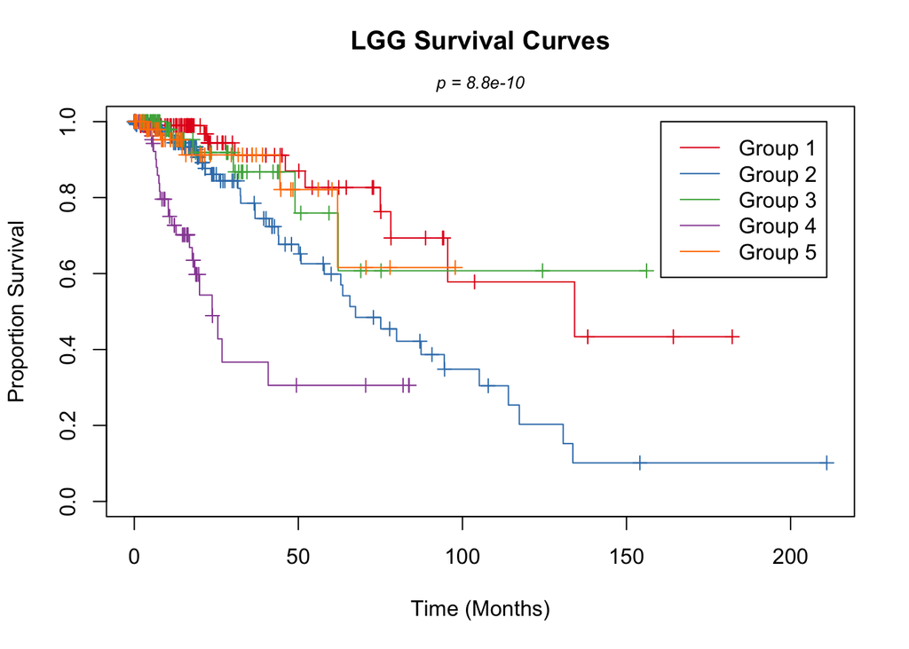

```r
#Plot survival curves
Plot.Group=NULL
Surv.Group=factor(egv.memb[names(Sur.l)])

if(is.null(Plot.Group)){
  t1= rep(T,length(Surv.Group))
}else{
  t1= egv.memb %in% Plot.Group
}
Sur.d1=Sur.d[t1]
Sur.l1=Sur.l[t1]
SurvObj=Surv(Sur.d1,event=Sur.l1==1,type='right')
egv.memb.f1=Surv.Group[t1]
sf=survfit(SurvObj ~ egv.memb.f1, conf.type = "log-log")
group.colors=c('#BEBEBE',brewer.pal((max(egv.memb)), 'Set1'))
flvs=as.integer(as.vector(sort(unique(egv.memb.f1))))
survtest.result=survdiff(SurvObj ~ egv.memb.f1,rho=0)
survtest.p.val <- 1 - pchisq(survtest.result$chisq,
                             length(survtest.result$n) - 1)
survtest.p.val=signif(survtest.p.val,2)
survplotnm=paste0(filepath,'/',Cancer.Code,'_Survival_Curves.pdf')
#pdf(survplotnm,width=8,height=6)
plot(sf,conf.int=F,col=group.colors[flvs+1],mark.time=T,
     xlab='Time (Months)',ylab='Proportion Survival')
title(paste0(Cancer.Code,' Survival Curves'),line=2.2)
mtext(paste0('p = ',survtest.p.val),side=3,
      line=0.5,font=3,cex=0.8)
lg.text=paste0('Group ',flvs)
lg.text[lg.text=='Group 0']='Ungrouped'
legend(max(Sur.d1),1,lg.text,lty=1,
       col=group.colors[flvs+1],xjust=1,yjust=1)
```

```r
#dev.off()
```

## Plot heatmap (including patient groups and subtypes)

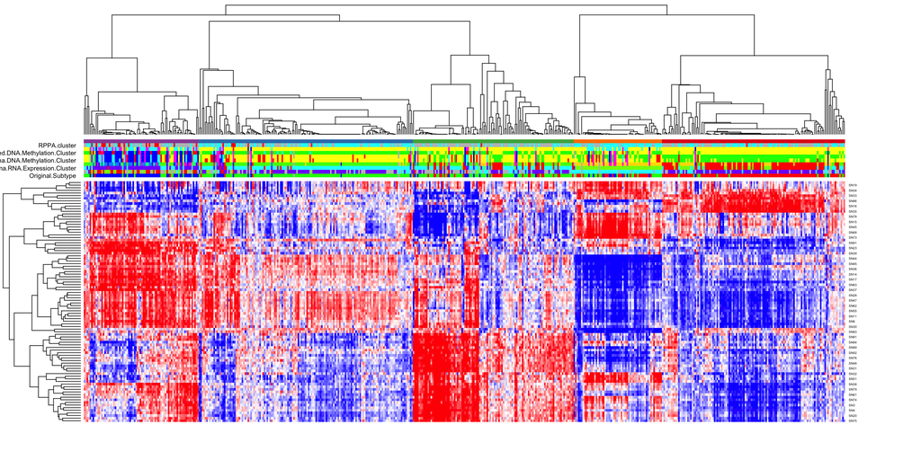

```r
#Plot heatmap (including patient groups and subtypes)
group.col=group.colors[as.integer(as.vector(egv.memb.f))+1]
colsidecolvector=as.matrix(group.col)
colv.cns='Group'

if('Subtype.Table' %in% save.data.nms){
  mt=Subtype.Table
  mt=as.matrix(mt)
  rownames(mt)=colnames(Sbn.Exp)
  mt[mt=='NA']=NA
  mt.legend=apply(mt,2,make.color)#,qualitative)
  mt.col=sapply(mt.legend,function(x)x$color)
  colsidecolvector=cbind(mt.col,colsidecolvector)
  colv.nnm=colnames(mt.col)
  colv.cns=c(colv.nnm,colv.cns)
}

colnames(colsidecolvector)=colv.cns

s.m=t(egv.m)
t11=quantile(s.m,0.95)
t12=quantile(s.m,0.05)
s.m[s.m<t12]=t12
s.m[s.m>t11]=t11
heatmap.nm=paste0(filepath,'/',Cancer.Code,'_Heatmap.pdf')
#pdf(heatmap.nm,width=16,height=8)
heatmap.31(s.m,col=heat.col3,margin=c(5,10),cexRow=0.5,ColSideColors = colsidecolvector,labCol=NA,
           Colv=egv.dendro,lwid=c(1,10),lhei=c(1,2,6),
           key=F)
```

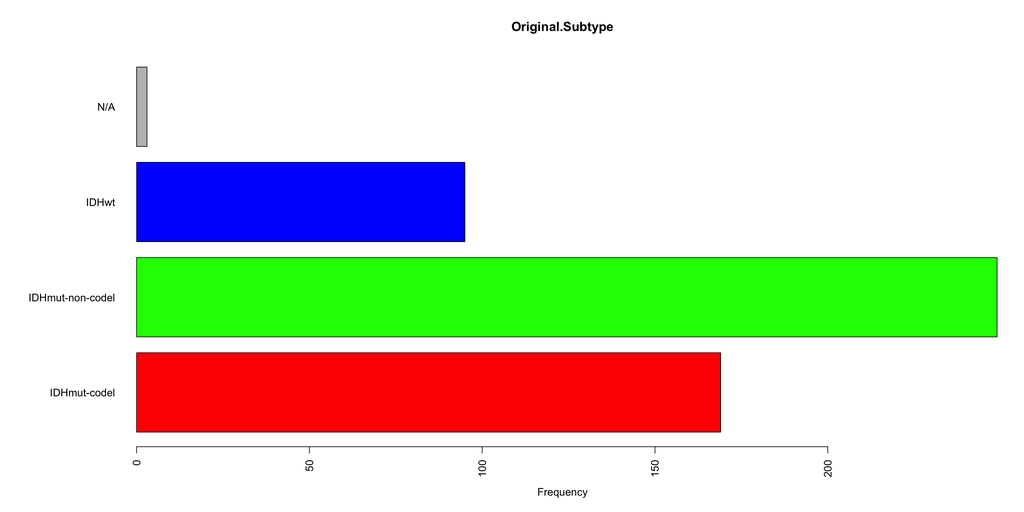

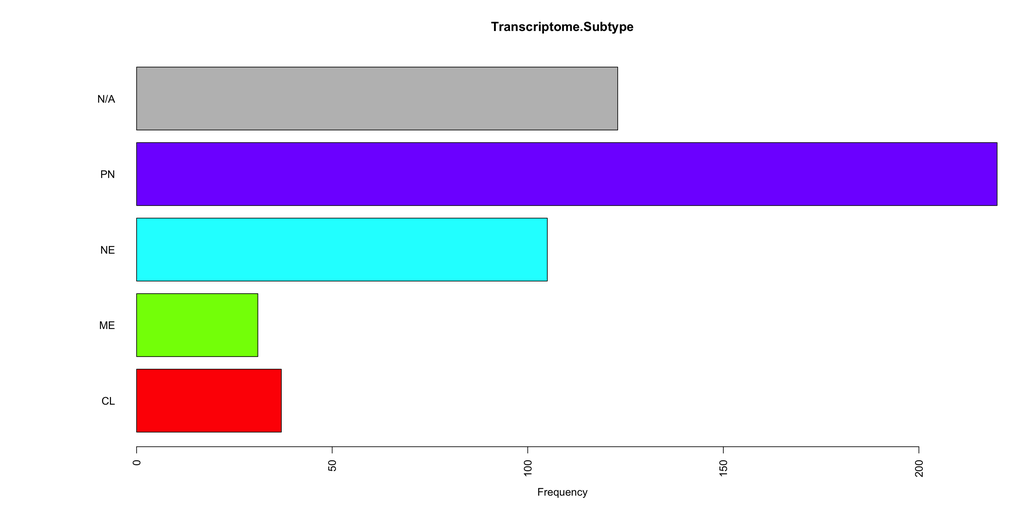

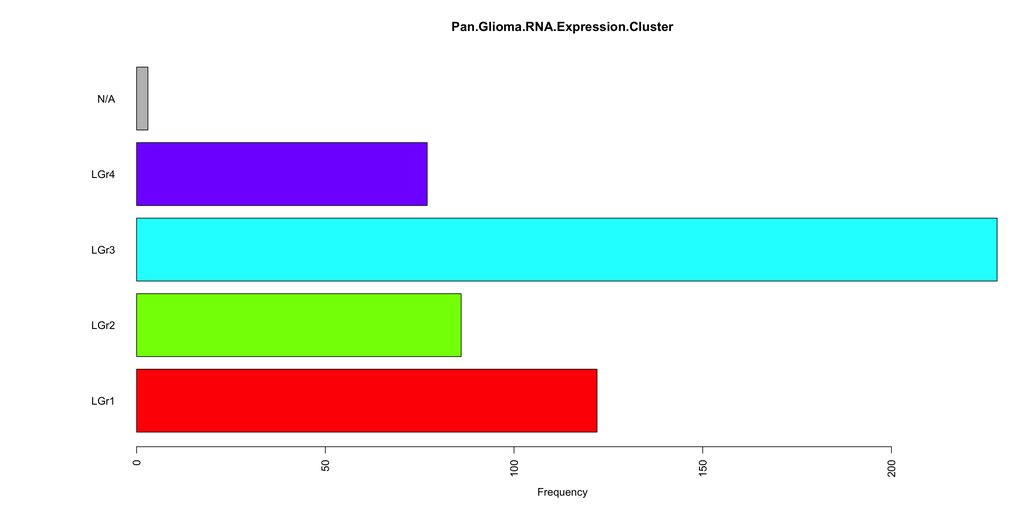

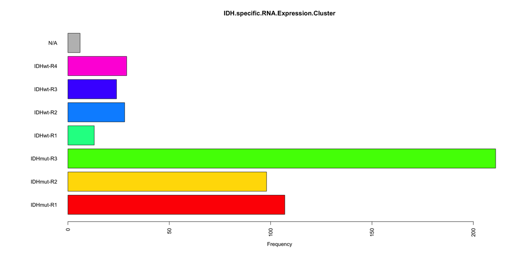

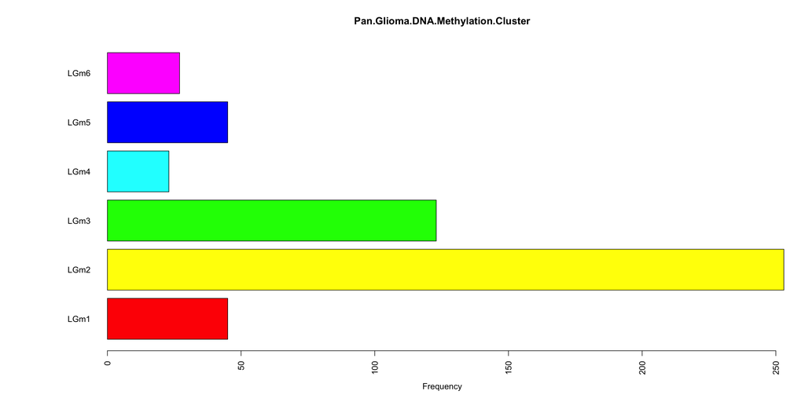

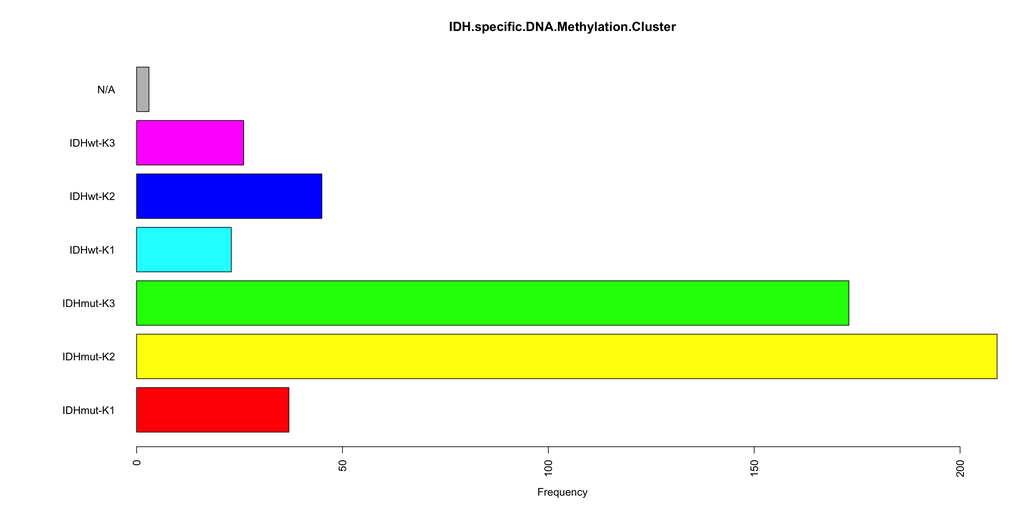

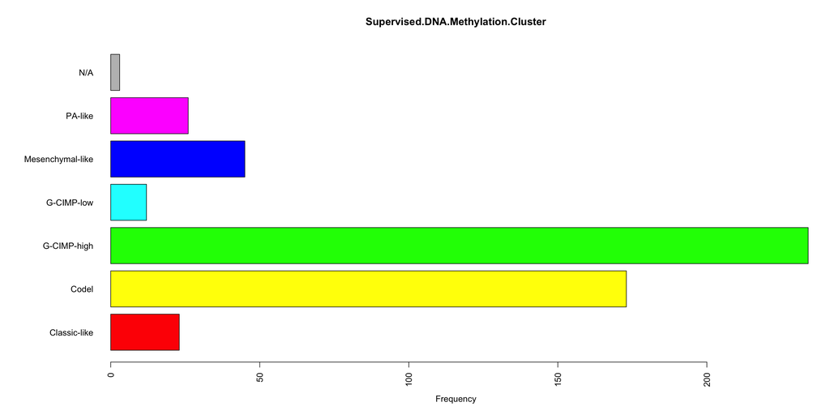

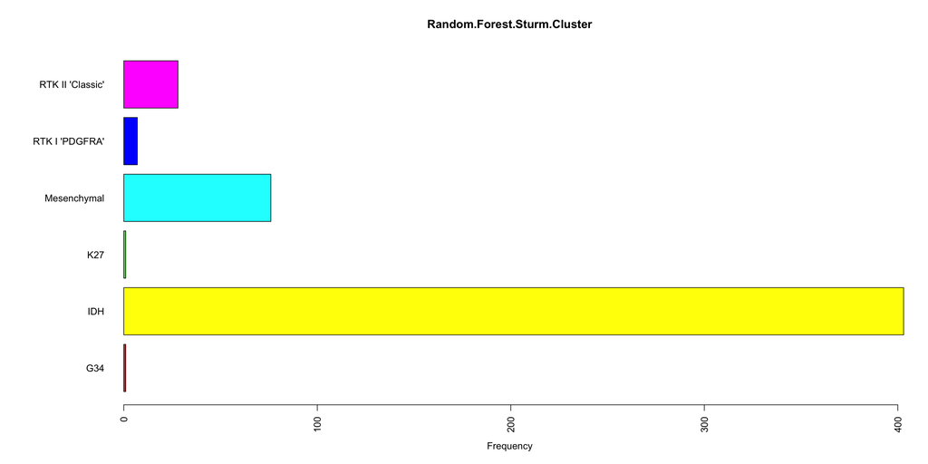

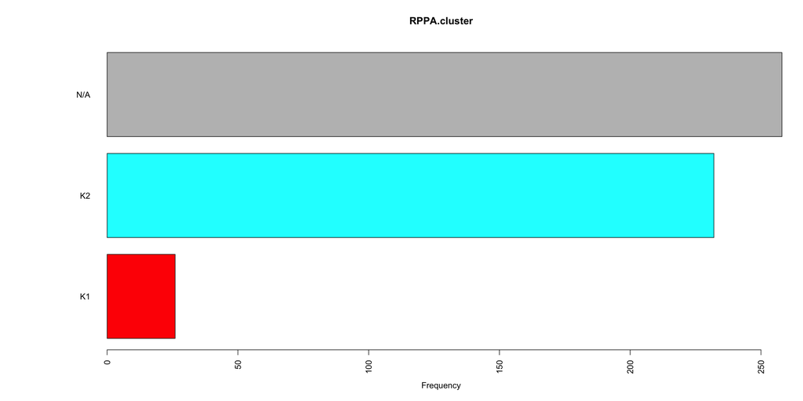

```r
#dev.off()

for(i in 1:length(mt.legend)){
  t1=colnames(mt.col)[i]
  t2=mt.legend[[i]]
  #temp.nm=paste0(filepath,'/',Cancer.Code,'_Heatmap_',gsub('\\.','_',t1),'_Legend.pdf')
  #pdf(file=temp.nm,width=6,height=4)
  plot.legend(t2,main=t1)
  #dev.off()
}
```

## Network State Plot

[figure not shown]

```r
#Network State Plot
fbn3.index=paste0('SN',1:length(f.Sbn.List))
fbn3.index=fbn3.index[fbn3.index %in% names(f.Sbn.List1)]
sn.sta=1
sn.end=length(f.Sbn.List1)
f.Sbn.List3=f.Sbn.List1[fbn3.index[sn.sta:sn.end]]

grps=max(egv.memb)
sub.n=length(f.Sbn.List3)
l.wids=c(1,rep(5,sub.n))
l.hgts=rep(c(1,rep(5,grps)),length(l.wids))
m.c.ns1=names(f.Sbn.List3)
m.c.ns2=paste0('Group',1:grps)
m.c.ns2.col=group.colors[1:grps+1]
l.matrix=matrix(1:((grps+1)*(sub.n+1)),nrow=grps+1)

nsnm=paste0(filepath,'/',Cancer.Code,'_Network_State_',sn.sta,'-',sn.end,'.pdf')
#pdf(file=nsnm,width=sum(l.wids),height=sum(l.hgts)/length(l.wids))
layout(l.matrix,widths=l.wids,heights=l.hgts)
ml1=max(abs(quantile(Sbn.Exp,c(0.05,0.95))))
cmar=par()$mar
par(mar=c(0,0,0,0))
plot.new()
box('plot',lwd=3,col='gray50')
for(j in 1:grps){
  plot.new()
  text(0.5,0.5,m.c.ns2[j],cex=5,srt=90,col=m.c.ns2.col[j])
  box('plot',lwd=3,col='gray50')
}
for(i in 1:sub.n){
  plot.new()
  text(0.5,0.5,m.c.ns1[i],cex=5)
  box('plot',lwd=3,col='gray50')
  gs=f.Sbn.List3[[i]]
  g1=induced.subgraph(Sbn.Network,gs)
  g2=induced.subgraph(Sbn.Network3,gs)
  E(g2)$lty=1
  g1=graph.union(g1,g2)
  E(g1)$lty[is.na(E(g1)$lty)]=2
  g1$layout=layout.auto(g1)
  V(g1)$frame.color='gray75'
  V(g1)$size=25
  V(g1)$label.font=2
  V(g1)$label.cex=2
  V(g1)$label.color='black'
  for(j in 1:grps){
    v.cols=get.color2(V(g1)$name,egv.memb==j,Sbn.Exp,ml1)
    plot(g1,vertex.color=v.cols)
    # plot(g1,vertex.size=V(g1)$size*2.5)
    box('plot',lwd=3,col='gray50')
  }
}
```

```r
par(mar=cmar)
#dev.off()
```